# P-values

Adam Raikes

February 19, 2017

# Purpose

The purpose of this slideshow is to discuss p-values and their correct interpretation. Understanding p-values is an essential component of frequentist statistics (the kind we are using this course) and their correct interpretation is exceedingly important.

# The Normal Distribution (1/2)

The start of framework is with the normal distribution. Recall that areas under the normal distribution reflect percentages of a population.

# The Normal Distribution (2/2)

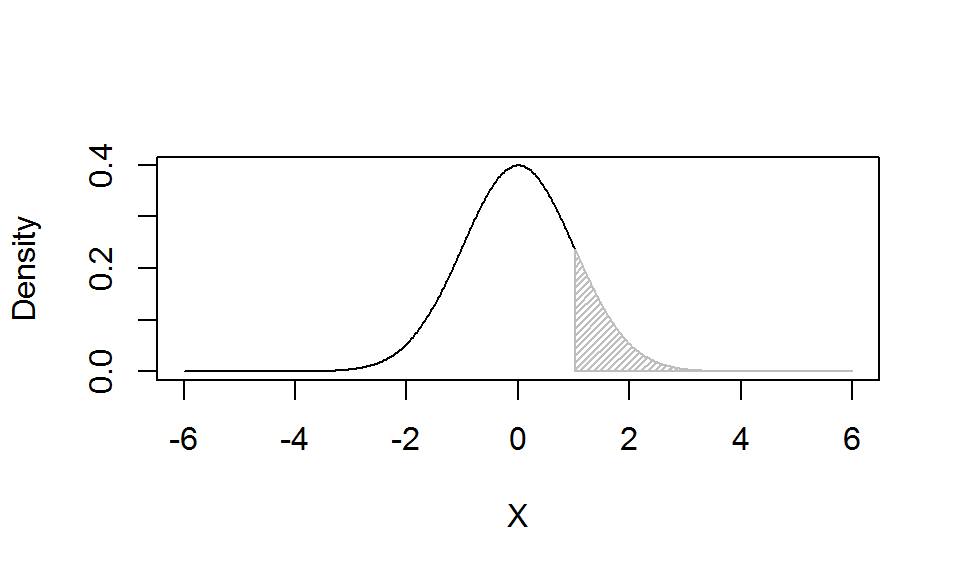

The area in the upper tail (the right side of the distribution) from 1 SD to $\infty$ is 15.87% of the population.

# The Normal Distribution (3/3)

- Recall that in all cases of statistical testing, we also specify an $\alpha$-level. Imagine that we take a large number of samples of the same size and from the same population. $\alpha$ proportion of samples in which we will conclude that our alternative hypothesis ($H_{A}$) is true when in fact the null hypothesis ($H_{0}$) is true.
- Recall also that, generally speaking, we set $\alpha = 0.05$
- Finally recall that our alternative hypothesis may be one of “greater than” (our observed difference is larger than our null hypothesis), “less than” (our observed difference is less than our null hypothesis), or two-tailed (either larger or smaller, it doesn’t matter).

# A “Greater Than” Alternative Hypothesis

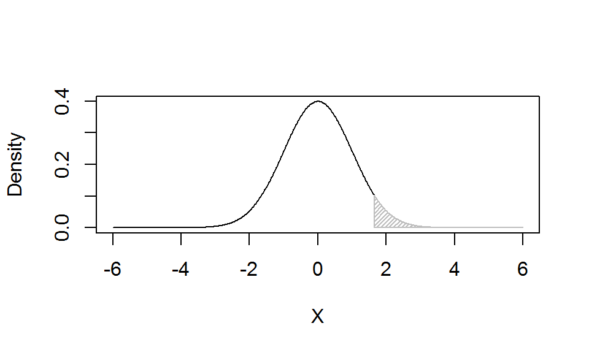

The shaded region reflects our alpha level. This shows that all of our $\alpha = 0.05$ region is on the right side of the distribution.

# A “Less Than” Alternative Hypothesis

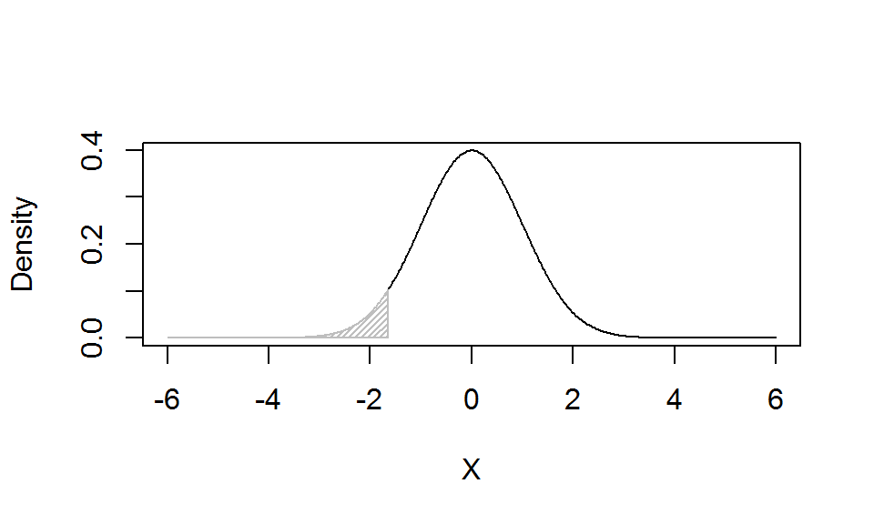

The shaded region reflects our alpha level. This shows that all of our $\alpha = 0.05$ region is on the left side of the distribution.

# A “Who Cares Which Way” Alternative Hypothesis (1/2)

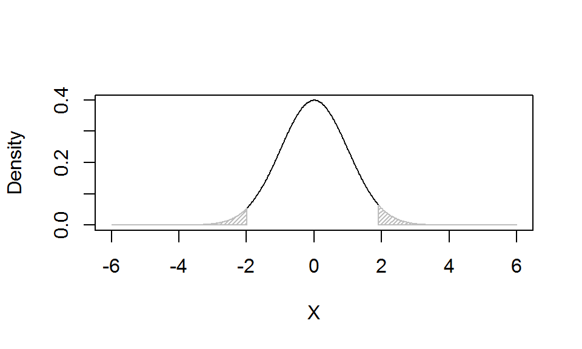

The shaded regions reflect our alpha level. This shows that our $\alpha = 0.05$ region is split between the upper and lower tails.

# A “Who Cares Which Way” Alternative Hypothesis (2/2)

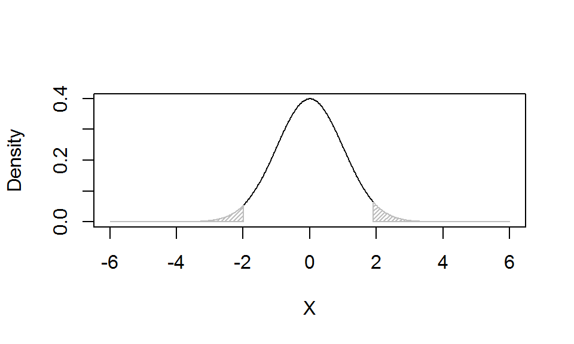

This means that the difference (either less than or greater than) must be larger than when we’re only considering a one-tailed test.

# Relating P-values and Alpha

Given the preceding characteristics of our $\alpha$ level with respect to tail regions, we can begin to relate our p-value to this. To compute a p-value, we first get a test statistic. This could be:

- Z-score (normal distribution)
- t (T-test)
- F (ANOVA)
- $\chi^{2}$

# Relating P-values and Alpha (1/4)

Each test statistic falls somewhere along the test-statistic distribution. For this level of introduction, we’ll consider the normal distribution (and recall that the T distribution is very similar).

# Relating P-value and Alpha (2/4)

What if we observed a Z-score of 2.0 under a two-tailed test for the normal distribution ($\alpha = 0.05$)?

# Relating P-values to Alpha (3/4)

The area under the curve to the right of Z = 2.0 is 2.28%.

# Relating P-values to Alpha (4/4)

Since we are considering a two-tailed test, we need to multiply this by two (to accommodate observing a difference this large in either direction. Thus for Z = 2.0 the two-tailed area is 4.56%. This is less than our $\alpha = 0.05$ (or 5%).

# So What?

So what can we conclude? In this case, we can conclude that we will observe a Z-score as large or larger (or as small or smaller for the negative side) as $\pm$ 2.0 in only 4.56% of the possible outcomes. It is unlikely that we will observe a value this large or larger if the true population value is 0.

# Applied to Differences

What about two-group differences? Consider the example we’ve been using in class for height. Let’s set up our testing parameters. We are considering the group differences between men and women.

- $H_{0}$: No gender difference in height
- $H_{A}$: Difference between genders (two-tailed)
- $\alpha$ = 0.05
- Women: $\bar{X}$ = 66.58; $\sigma$ = 3.06
- Men: $\bar{X}$ = 71.33; $\sigma$ = 3.14

# Results

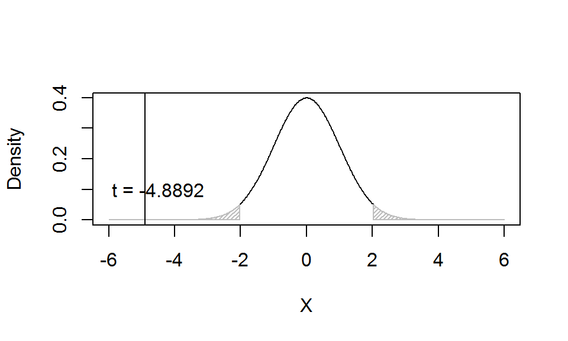

# Results

The area to the left of that t-value is 0.001%. Recall that, since we are considering a two-tailed possibility (difference in either direction), we multiply by two to accommodate the possibility of a difference this large on the other end of the disribution. Thus, 0.002%.

This is much smaller than our alpha level (5%). Thus we would conclude that we have observed a larger difference in average heights **than what we would expect if the null hypothesis is true.**

# Results

That value is our p-value (0.002%). It tells us the proportion of samples of the same size and drawn from the same population that will have a difference in average heights that large or larger **if the null hypothesis is actually true.**

In this case, very few samples will exhibit this large of a difference.

# What p-values are not

P-values do not tell us:

- The probability that the alternative hypothesis is true.
- The probability that the data were produced by random chance alone.
- that there is less than a 5% chance that the null hypothesis is true
- that there is less than a 5% chance we comitted a Type I error
- that there is a 95% chance that the results could be replicated in a repeat study